# R package BayesTwin: Example analysis (Simulated data)

Inga Schwabe

This document illustrates how the R package BayesTwin can be used to analyse item-level twin data.

#### First steps

Before you can actually use BayesTwin, you need to take a few steps:

- If necessary download and install the most recent version of [R](https://cran.r-project.org/bin/windows/base/) and potentially a user interface to R like [R Studio](https://www.rstudio.com/products/rstudio/download/)
- Install the most recent version of [JAGS](http://mcmc-jags.sourceforge.net/)

#### Install and load package

Then you will need to install and load the package in R:

```r
#install.packages("BayesTwin")
#library(BayesTwin)
library(devtools)
install_github("ingaschwabe/BayesTwin")
library(BayesTwin)
```

#### Data-simulation

We first simulate some data to show how the main function of BayesTwin works:

```r
simulated_data = simulatetwin(n_mz = 2000, n_dz = 5000, var_a = 0.5, var_c = 0.3,
                              var_e = 0.2, model = "ACE", n_items = 40, ge = FALSE,
                              irt_model = "1PL")
```

The code above simulates item-level data of 2000 MZ twin pairs and 5000 DZ twin pairs under the ACE model. We just simulated item-level data of 2000 MZ twin pairs. For the generation of the item data, the one parameter logistic model (1PL) is used, meaning that we simulated dichotomous (0=FALSE,1=TRUE) item data as is typical for for example cognitive performance data (e.g., mathematical ability). The item data is saved in the object “simulated_data”.

```r
head(itemdata_mz[1:5], 2)
```

```
## [1] 0 1
```

The same logic applies to the data of DZ families. For example, these are the item responses for the second twin of the first 2 DZ twins families:

```r
head(itemdata_dz[41:80], 2)
```

```
## [1] 0 0
```

#### Run the analysis

Now we can run the analysis using the main function of the BayesTwin package and save it in an object:

```r
results = IRTtwin(data_mz = itemdata_mz, data_dz = itemdata_dz, twin1_datacols_p = 1:40, twin2_datacols_p = 41:80, decomp_model = "ACE", irt_model = "1PL", ge = TRUE, n_iter = 7000, n_burnin = 5000, n_chains = 1)
```

The code above analyses the data under an ACE and one parameter logistic (1PL) model including a genotype-environment interaction (GxE). As a burn-in, 5000 iterations are used, followed by an additional 7000 iterations.

We first have a look at the variance components:

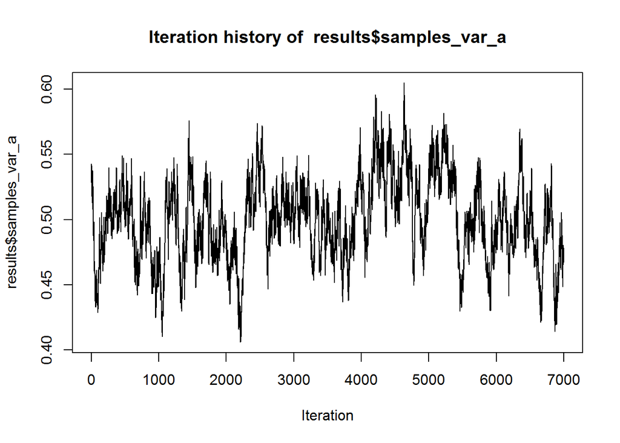

```r
plotbayestwin(results$samples_var_a, type = "trace")
```

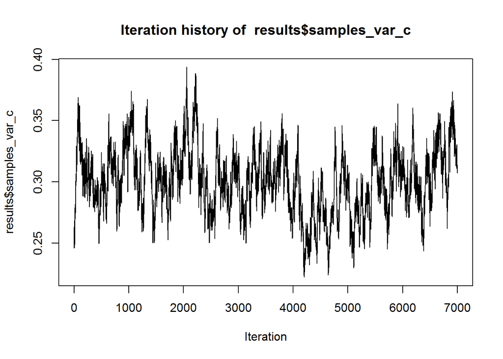

```r
plotbayestwin(results$samples_var_c, type = "trace")
```

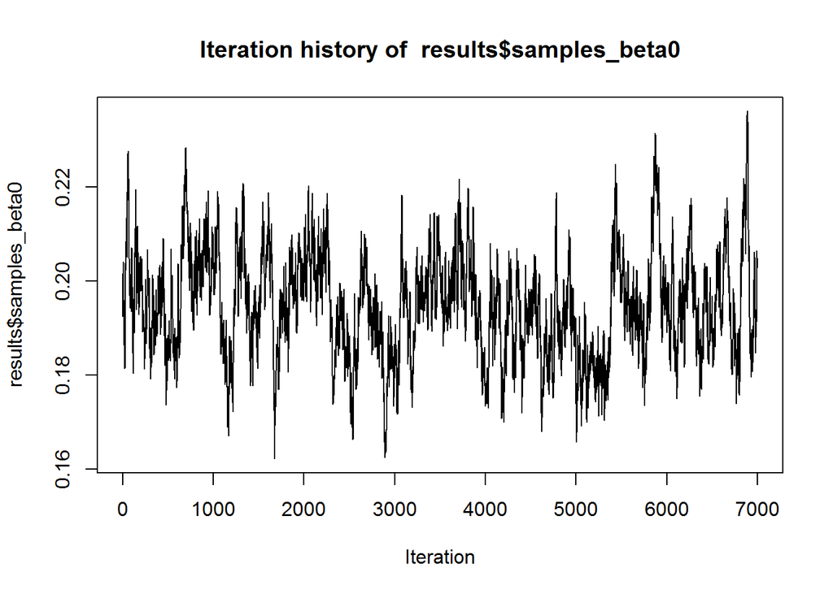

```r
plotbayestwin(results$samples_beta0, type = "trace")
```

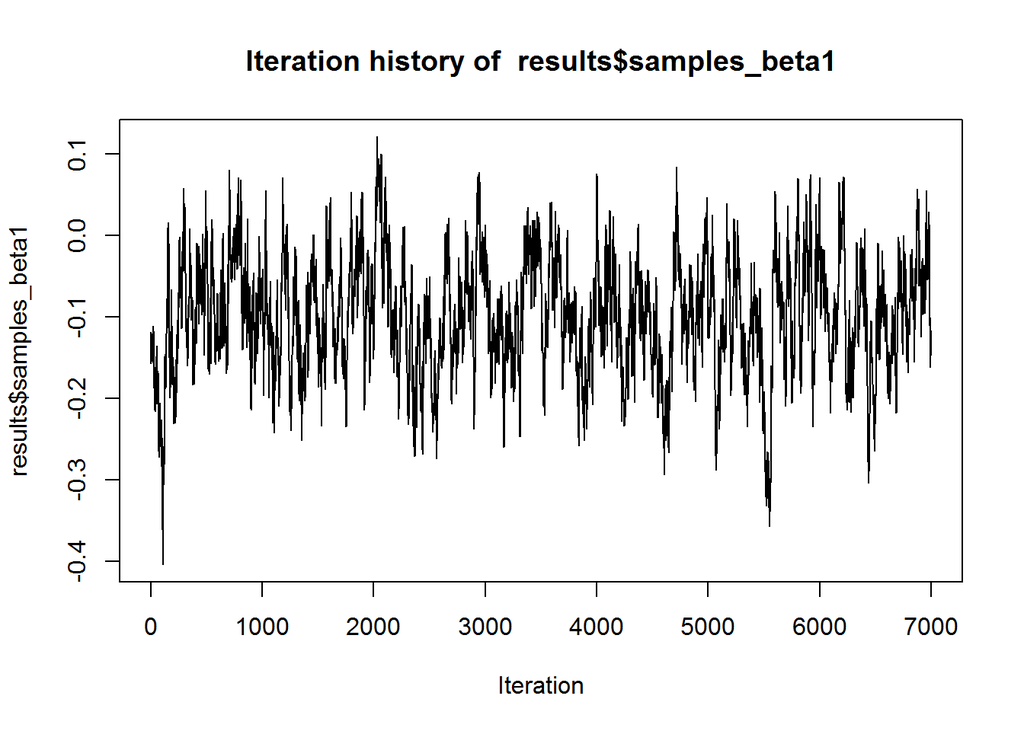

```r
plotbayestwin(results$samples_beta1, type = "trace")
```

The trace plots look reasonable: there is no part where it seems as if the chain is stuck or in other words: the full range of the posterior distribution seems to be covered. We then look at item parameters. As we used a 1PL, only difficulty paramters were estimated:

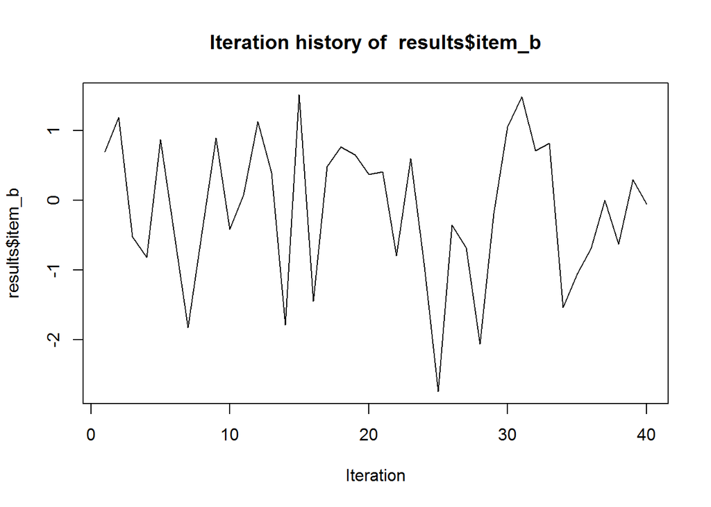

```r
plotbayestwin(results$item_b, type = "trace")
```

In case that we are not convinced that the MCMC algorithm has convergened to the posterior distribution, the analysis should be run again, this time with a higher number of burn-in iterations.

In case that we are convinced that the algorithm converged, we can have a look at the results:

```r
summary(results)
```

```
##                                    varA       varC      beta0       beta1
## Posterior mean               0.50006998 0.30051973 0.19477207 -0.09877121
## Posterior standard deviation 0.03158809 0.02684237 0.01108473  0.07166238
## Lower 95% HPD interval       0.43691000 0.24789000 0.17358000 -0.24480000
## Upper 95% HPD interval       0.56026000 0.35224000 0.21619000  0.03644000
## attr(,"class")
## [1] "bayestwin"
```

..and plot the posterior density:

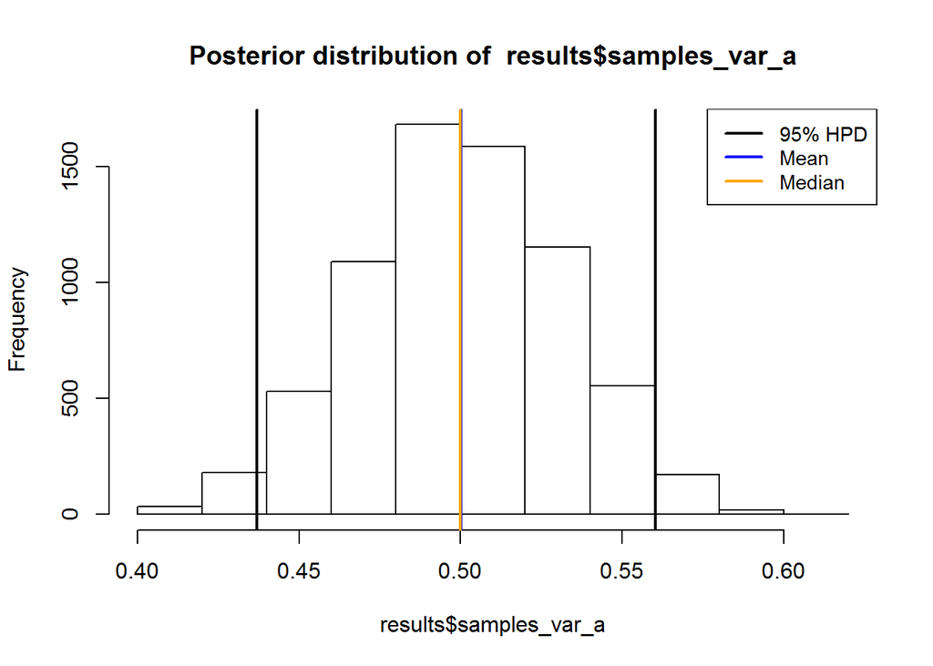

```r
plotbayestwin(results$samples_var_a, type = "density")
```

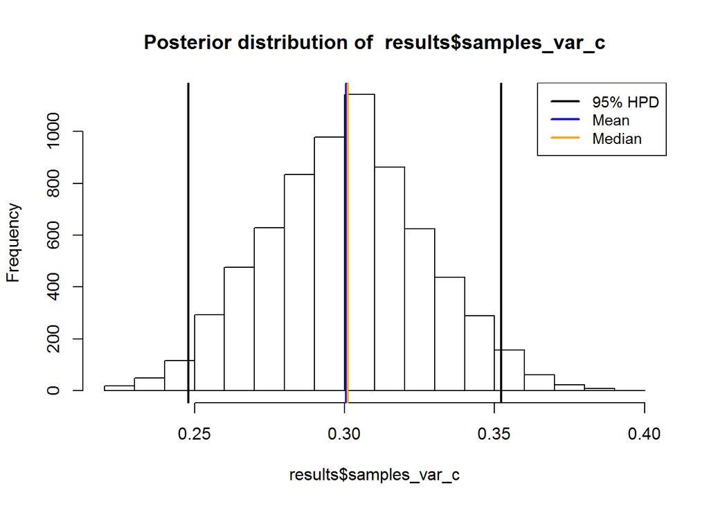

```r
plotbayestwin(results$samples_var_c, type = "density")
```

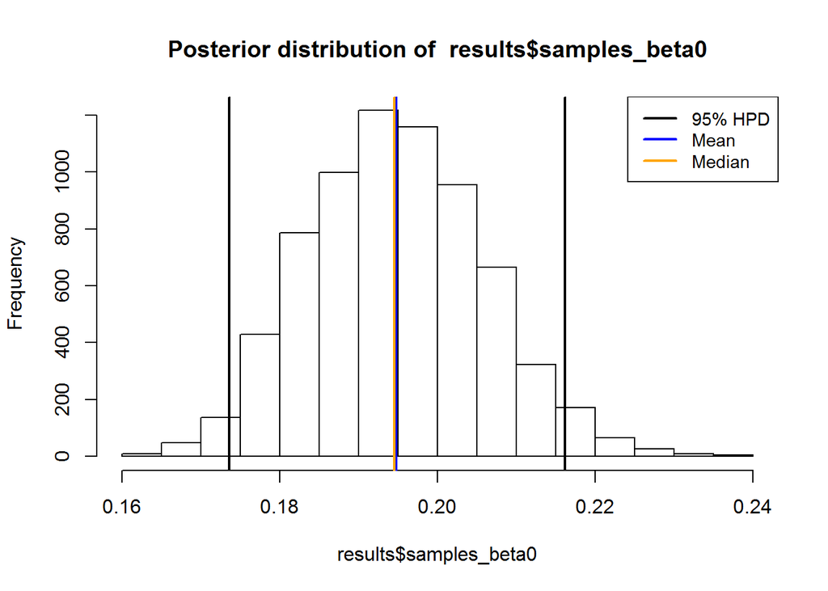

```r
plotbayestwin(results$samples_beta0, type = "density")
```

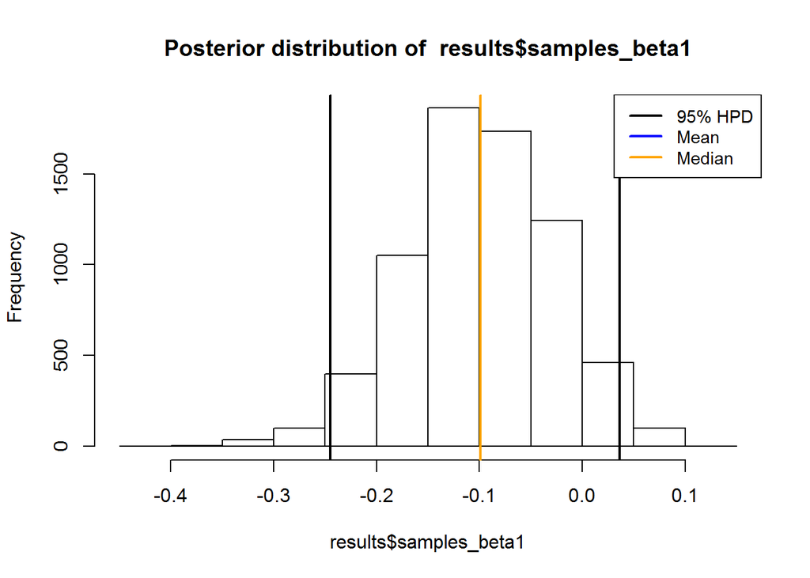

```r
plotbayestwin(results$samples_beta1, type = "density")
```

Using the function geplot, we can also plot the 95% credibility region of the GxE effect:

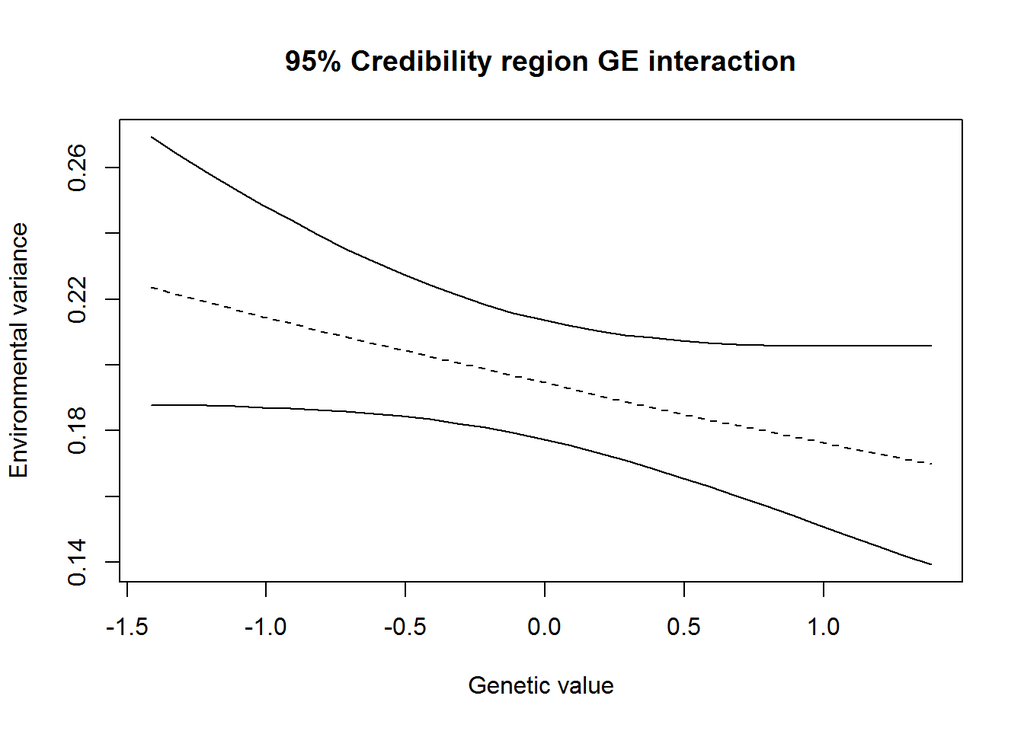

```r
geplot(results$var_a, results$samples_beta0, results$samples_beta1)
```